# Meta-Batch

## 初步想法与设计

噪声问题、对抗样本的存在在图像分类任务会有深刻的影响。同样，这些问题也会影响到计算机视觉涉及到回归任务的学习，比如目标检测，关键点的定位。回归任务中其实也在包含了分类的内涵在里面，除此外，还需要确定位置信息，即what it is and where it is。而噪声样本的存在，依旧会影响DNN对此类问题的数据流形的决策边界的判断。

因为深度神经网络的强大的表示能力和记忆特性[$[1]$](http://bengio.abracadoudou.com/publications/pdf/zhang_2017_iclr.pdf)在训练时能够拟合无论来自数据还是标签的噪声，会让模型学到过于复杂的假设，而减缓收敛，失去指定目标的泛化识别能力。又因为深度神经网络模型[优先学到简单的模式](https://arxiv.org/abs/1706.05394)，在训练早期碰到难度较大的样本，不利于寻找数据流形中明显的决策边界，所以我们在训练前期应该让模型看到更简单一些的样本，保留一小部分难样本对梯度回传的贡献。这个想法包含了**AdBoost中用数据来决定模型学习的理念**或者说是OHEM（在线难例挖掘）的逆向思维。在训练的后期，我们再减少模型对困难样本学习的限制，同时，在拟合较为困难甚至带有噪声的样本时，避免对之前学习的样本的遗忘。

在以上论述基础上，我大致想出**Meta-Batch**的方法：该方法是一个简单高效的方式，它类似于在线学习，但又不完全等价于它，因为每个周期间的batch学习不再像传统mini-batch那样保持独立，而是通过meta属性的取值而存在前后关联，使得模型对每个迭代学习具有记忆性，即每次迭代学习所参考的包括了模型的过去历史学习经验，涉及到了元学习meta-learning的范畴，即learn-to-learn，而属性的设计又有部分人工干预，这部分我主要还是受到神经网络的记忆特性的启发。

具体方法是：

在训练模型的每个周期内，我们规定每个样本最多只被学习一次。我们为每个样本，建立唯一的index，然后为每个样本index关联Meta属性，这里我们仅仅定义了难度系数D和遗忘程度F这两个属性，它不是超参数，这两个属性随周期性的学习发生变化。

- 难度系数D,由历史的学习经验和当前阶段的loss获取，来决定在每个batch学习中，我们是否要根据样本的学习难度，舍弃此实例对梯度反向传播的贡献。原则是：训练早期舍弃较难的样本。
- 遗忘程度F，由历史的学习经验获取，主要来决定我们是否要重拾一些被难度系数准则所舍弃的实例，来进一步增强模型的鲁棒性。原则是：训练后期额外加入被舍弃次数较多的样本，另外，选择部分较易的样本使模型继续保持泛化能力。

前者在训练前期发挥主要作用，后者在训练中后期，模型有将强的表示能力后，发挥主导的作用。

此理念指导下可以设计出不同类型和性质的属性，其定义方式也可以是灵活的。

在每个周期中batch迭代阶段，我们为batch中的每个样本的loss，然后我们根据loss和周期epoch重新计算该样本的难度系数D和F，决定哪些样本的loss需要梯度回传，哪些被抛弃。其中，D和F的计算方式需要精心考虑。我们设计了如下算法。

[1](http://bengio.abracadoudou.com/publications/pdf/zhang_2017_iclr.pdf)[Understanding deep learning requires rethinking generalization. (ICLR), 2017.](http://bengio.abracadoudou.com/publications/pdf/zhang_2017_iclr.pdf)

[2](https://arxiv.org/abs/1706.05394)[Arpit, Devansh et al. “A Closer Look at Memorization in Deep Networks.” ICML (2017)](https://arxiv.org/abs/1706.05394)

```python
import plotly.graph_objs as go
fig = go.FigureWidget()
# Display an empty figure
fig

# Add a scatter chart
fig.add_scatter(y=[2, 1, 4, 3])
# Add a bar chart
fig.add_bar(y=[1, 4, 3, 2])
# Add a title
fig.layout.title = 'Hello FigureWidget'
fig
```

[output not shown]

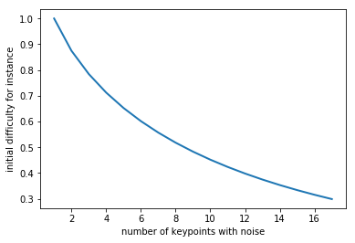

```python
import numpy as np
import matplotlib.pyplot as plt
num_keypoints=[i+1 for i in range(17)]
noise=0 #标记但不可见点
w=np.array(num_keypoints)
beta=2  #控制衰减
lamda=np.exp(1/beta)+1  #让标注点数量为1的难度值D设为最大为1
p=lamda*(1-1/(1+np.exp(-np.sqrt(w-noise)/beta)))
plt.plot(w,p,lw=2)
plt.xlabel('number of keypoints with noise')
plt.ylabel('initial difficulty for instance')
plt.show()
```

#### 难度系数D与遗忘程度F

上述曲线反映了，我们根据给定的关键点标注数量为每个实例设定了初始学习难度:

规定遗忘程度F的取值为$[0,1]$,值越大，遗忘程度越高！ 所有样本的初始遗忘程度为均为1

#### 算法设计

###### 版本 1

# :周期循环

```
#:每个周期内打乱数据集，循环加载一个Mini—batch,计算一个mini-batch下的输出loss
    1.根据模型输出的loss，由大到小排序一个Mini-Batch中的所有样本$S_{all}$
    2.按照CSR在一个Batch中选择一定比例的样本集S_{csr}，考察这些样本的难度。其余样本设为S_{easy}
    3.难：如果S_{csr}中样本难度较大(超过设定阈值)，抛弃该样本对梯度回传的贡献，同时增加其遗忘程度的数值，增量为delta
    4.中：如果S_{csr}中样本难度一般(小于设定阈值)，保留该样本对梯度回传的贡献，同时减少其遗忘程度的数值，减量为delta
    5.易：对于S_{easy}中的样本，保留该样本对梯度回传的贡献，同时减少其遗忘程度的数值，减量为2*delta
    6.对于S_{all}的样本，重新计算其难度，新难度=1/2*(旧难度+遗忘程度)
```

此设计还没有将 中后期如何处理难度较大，即被抛弃次数较多的样本 考虑在内。

## 二次设计与实验

#### 参考依据

A Closer Look at Memorization in Deep Networks中的一些结论：

1. DNN优先使用模式，而不是粗暴式的记忆学习来拟合数据，噪声数据的拟合和真实数据的拟合是存在本质区别，粗暴学习不能让模型捕捉到数据之间的模式和特征，
2. DNN的记忆与泛化能力取决于网络架构、优化程序以及数据本身
3. DNN 首先学习简单的模式，简单的样本可以作为模式学习的依据，可帮助模型更快地学习数据流形中的决策边界
4. 数据集中存在一定比率的临界样本（critical sample ratio），临界样本的存在影响模型对数据的假设变得复杂

#### 想法来源

1. 有效的学习算法（模型+训练程序）可以为数据寻找到一个更合理的假设
2. DNN优先从简单样本中学习到模式，
3. 方法是一般的，人体关键点回归是一个实际的具体应用：

   a.关键点的数量和是否遮挡会带来很多噪声干扰的存在， b.数据集中样本的外观与姿态变化差异较大 c.头部关键点与身体关键点的学习难度差别也较大！

#### 原则：

- 训练前期： 模型学习更简单的样本，保留一小部分难样本对梯度回传的贡献
- 训练后期: 减少模型对较困难样本学习的限制，抛弃极其困难的样本

#### 特点：

每个周期间的误差学习不再保持独立，而是通过Meta属性的取值而存在前后关联，使得模型对每个迭代学习具有记忆性，即每次迭代，参考了模型的过去历史学习经验

#### 具体设计与简单的实验（写在了PPT里面）

[figure not shown]

拟去掉难样本的集中学习阶段，把它渐进地覆盖到整个学习过程

[figure not shown]

新的难度系数=旧难度系数*0.5+遗忘程度*0.5的公式，是我人工设计，并没有什么依据或者理论做支持，我这样计算的目的是：

- 让难度系数尽可能参考上一步的难度，继续维持，但因为随着模型的学习，样本的整体难度在降低
- 让学习次数较少（遗忘程度较高）的样本保持较大的难度。只有在计算得到它的loss值较小的时候，才会让模型学习它，减少其遗忘程度，这样意味着样本的难度降低并不是来自偶然，而是模型的表示能力提升导致。

#### ResNet18 不同噪声等级（0，0.3，0.7）下的对比实验

[figure not shown]

#### 实验结果分析

1. 没有达到预期效果！模型的泛化性能还是受数据本身的影响更大。但只取部分loss作梯度回传，依旧可以使得模型保持原先的泛化能力
2. 在难度样本的loss被加入学习时，模型会出现一个短暂的性能下降，这是由于非典型（临界？）样本的突然出现让模型原本寻找的假设发生了变化。
3. ResNet18的有效容量不足以拟合所有的包含噪声的数据，加上训练周期迭代次数不够，带噪声的学习没有讲训练误差收敛至0附近
4. Loss值作为学习难度的参考是否有足够的证据，该怎么利用loss？CIFAR-10的初始难度系数我使用了随机设置，初始值是不是很影响？
5. 算法的设计上比较粗糙，**Meta属性的难度系数值的计算，是否真正代表特定样本在某个周期的实际学习难度**，值得怀疑！如何更新计算难度的公式也需要进一步推敲。

#### 下一步工作

1. 考虑去除hard-learning stage 让困难样本的加入不突然，调节CSR在不同周期的大小，使得困难样本学习的加入更加平滑
2. 应用在人体关键点任务keypoints回归的任务上，使用MSCOCO数据集，为每个样本与关键点建立难度。
3. 初步看了MentorNet（2018 ICML）的工作，有很多可以借鉴的地方.
4. 相关的工作self-paced learning（2010 NIPS）和在线学习 self-paced Curriculum （2015 AAAI）都强调了样本的学习顺序问题和学习难度问题，但对于单个样本的学习难度并没有准确的定义，而loss的大小跟样本学习难度是相关的，但是如何定义难度是一个难题。但直觉上和一些研究的实验结果表明，考虑样本的难度和学习顺序是可以提升模型泛化性能的。